# Tests statistiques et multiplicité

Python works with packages. A large number of packages can be dowloaded all together in the Anaconda environment. Start downloading here (version >3) https://www.anaconda.com/download/ Anaconda comes with

- Spyder, a GUI for python
- Jupyter Notebook, how to create great documents

Enjoy!

Bee careful :

- Python is sensible to spaces in the beginning of lines,
- Python is sensible to number type : $3$ and $3.$ are totally different: *integer* and *float* types.

```python
import warnings
warnings.filterwarnings('ignore')

import numpy as np
import numpy.random as npr
import matplotlib.pyplot as plt
import pandas as pd
```

# Les données

Le fichier **Supra_data_s.txt** contient les données relevées lors d’une étude prospective (*SUPRA - Supervision of the PRogression of Atherosclerosis in HIV-1 infected patients*) parmi des participants de la cohorte Aquitaine. L’étude portait sur l’évaluation des facteurs de risques associés aux maladies cardiovasculaires chez les patients infectés par le VIH, en utilisant le marqueur *IMT - intima media thickness of the carotid arteries* (colonne **mesure**). L’étude comportait le relevé d’autres marqueurs connus comme étant des facteurs de risques des maladies cardiovasculaires : **sexe** (SEXE = 1 si homme, 2 si femme), **age** (AGE en années), **taille** (en cm), **poids** (en kg), **habitudes liées au sport** (0=non sportif, 1=sportif), **tabac et prise d’alcool** (0=consommation nulle, 1=consommation occasionnelle, 2=consommation régulière).

```python
data = np.loadtxt("Supra_data_s.txt",skiprows=1)
header = ["SEXE","AGE","taille","poids","tabac","SPORT","mesure","alcool"]
print(data[0:10,:])
```

```
[[  1.    33.   170.    70.     1.     0.     0.52   1.  ]
 [  2.    33.   177.    67.     2.     0.     0.42   1.  ]
 [  2.    53.   164.    63.     1.     0.     0.65   0.  ]
 [  2.    42.   169.    76.     1.     1.     0.48   1.  ]
 [  2.    53.   152.    54.     0.     0.     0.45   1.  ]
 [  2.    50.   162.    53.     2.     0.     0.49   1.  ]
 [  1.    22.   181.    72.     0.     1.     0.42   1.  ]
 [  2.    26.   162.    61.     1.     1.     0.45   1.  ]
 [  1.    50.   170.    80.     0.     0.     0.65   2.  ]
 [  2.    47.   178.    73.     0.     0.     0.52   1.  ]]
```

### Creation du BMI

**QUESTION** Créer la variable **BMI** *Indice de Masse Corporelle* telle que $$ BMI=\frac{Poids}{Taille^2}, $$ et l'ajouter au dataset.

```python
bmi = data[:,3:4]/data[:,2:3]**2
data = np.concatenate((data,bmi),axis=1)
header = header + ["bmi"]
print(data.shape)
```

```
(110, 9)
```

### Tests unitaires

```python
from scipy import stats
```

### Test de student

#### Comparaison à une moyenne connue

**QUESTION** On suppose que l’IMT moyen dans la population générale est de $0.5$. L’échantillon de l’étude est-il représentatif de la population générale en terme d’IMT sous un seuil $\alpha=0.05$ ?

Pour ça on utilisera le test de *Student* en comparaison à une moyenne connue.

**scipy.stats.ttest_1samp** permet de faire ça.

```python
imt_sample = data[:,6]
print(stats.ttest_1samp(imt_sample,0.5))
```

```
Ttest_1sampResult(statistic=3.6639873759501076, pvalue=0.00038515402414989104)
```

Pour un seuil $\alpha=0.05$, il nous est nécessaire de **rejetter** l'hypothèse d'appartenance de la population d'étude à la population générale.

#### Visualisation de données, la *boite à moustache* ou *boxplot*

**QUESTION** Réaliser la boîte à moustache de l’**IMT** en fonction de la variable **sexe**.

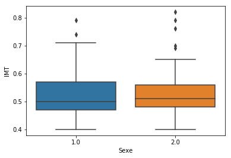

```python
import seaborn as sns

bp = sns.boxplot(x=data[:,0], y=data[:,6]).set(xlabel='Sexe',ylabel='IMT')
```

On peut voir que les distributions semblent être les mêmes.

**QUESTION** Utiliser un test de comparaison de moyenne de *Student* à $2$ échantillons indépendants pour s'en assurer, ou pas.

Repérer les positions des hommes et des femmes :

```python
men = [i for i,x in enumerate(data[:,0]) if x==1.]
women = [i for i,x in enumerate(data[:,0]) if x==2.]
```

Ce qui permet de sélectionner les données d'**IMT** pour les femmes d'un côté et les hommes de l'autre.

```python
imt_men = data[men,6]
imt_women = data[women,6]
```

- Première étape : Test de l'hypothèse de l'égalité des variances :

  On utilise le F-test et l'on compare à $\alpha=0.05$

```python
F = np.var(imt_men)/np.var(imt_women)
p_value = stats.f.cdf(F, len(men)-1, len(women)-1)
print(p_value)
```

```
0.34570300779740415
```

Nous pouvons donc passer à la deuxième étape.

- Deuxième étape : Test de Student à $2$ échantillons :

```python
print(stats.ttest_ind(imt_men,imt_women))
```

```
Ttest_indResult(statistic=-0.20707837588744438, pvalue=0.8363385826501982)
```

La p-value est supérieure à $\alpha=0.05$ donc il faut conserver l'hypotèse $\mathcal{H}_0$ *: Les deux populations ont le même **IMT** moyen.*

**INTERPRETATION**

**QUESTION** Tracer un Boxplot de l'**IMT** en fonction de la variable **tabac**

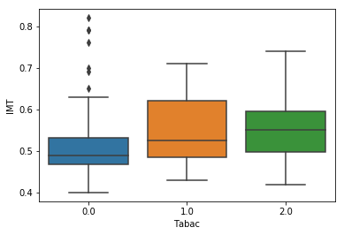

```python
bp = sns.boxplot(x=data[:,4], y=data[:,6]).set(xlabel='Tabac',ylabel='IMT')
```

```python
tabac_0 = data[[i for i,x in enumerate(data[:,4]) if x==0.],6]
tabac_1 = data[[i for i,x in enumerate(data[:,4]) if x==1.],6]
tabac_2 = data[[i for i,x in enumerate(data[:,4]) if x==2.],6]

F, p = stats.f_oneway(tabac_0,tabac_1,tabac_2)

print(p)
```

```
0.08181858704650491
```

La p-value est supérieure à $\alpha=0.05$ donc il faut conserver l'hypotèse $\mathcal{H}_0$ *: Les trois populations ont le même **IMT** moyen.*

**INTERPRETATION**

**QUESTION** Binariser la variable **mesure** en mesure_bin qui vaut $0$ si **mesure** est inférieure à $0.5$ et $1$ sinon.

```python
mesure_bin = [0]*len(data[:,0])
mesure_1_pos = [i for i,x in enumerate(data[:,6]) if x>=0.5]
for i in mesure_1_pos:
    mesure_bin[i] = 1
print(mesure_bin)
```

```
[1, 0, 1, 0, 0, 0, 0, 0, 1, 1, 0, 0, 0, 0, 0, 1, 0, 0, 1, 0, 0, 0, 0, 0, 0, 1, 0, 0, 1, 1, 1, 1, 1, 0, 1, 0, 0, 0, 1, 1, 0, 0, 1, 1, 1, 0, 1, 1, 0, 1, 1, 0, 1, 0, 0, 0, 0, 1, 1, 1, 0, 0, 1, 0, 0, 1, 0, 1, 1, 1, 1, 1, 0, 1, 0, 1, 1, 1, 1, 1, 1, 1, 1, 0, 1, 1, 1, 1, 0, 1, 0, 1, 1, 1, 1, 0, 1, 1, 0, 0,…
```

**QUESTION** Creer une table de contingence qui permette de croiser la variable **mesure_bin** et la variable **tabac**

```python
data_contin = np.array([data[:,4],mesure_bin]).T
pd_data = pd.DataFrame(data=data_contin,columns=["Tabagisme (X)","IMT (Y)"])
poids_tabagisme = pd.crosstab(index=pd_data["Tabagisme (X)"],
                           columns=pd_data["IMT (Y)"])
poids_tabagisme
```

| IMT (Y) Tabagisme (X) | 0.0 | 1.0 |
| --- | --- | --- |
| 0.0 | 41 | 31 |
| 1.0 | 5 | 13 |
| 2.0 | 5 | 15 |

**QUESTION** Faire un test du $\chi^2$ permettant de tester le lien entre le tabagisme et l'IMT binarisé.

```python
chi2, pvalue, degrees, expected = stats.chi2_contingency(poids_tabagisme)
print(pvalue)
```

```
0.00903901150181748
```

La p-value est inférieure à $\alpha=0.05$ donc il faut rejetter l'hypotèse $\mathcal{H}_0$.

**INTERPRETATION**

# Multiplicité des tests

Afin d'ajuster les tests, on chargera la **librairie** `statsmodels.stats.multitest` que l'on renomera `smm`

```python
import statsmodels.stats.multitest as smm
```

La fonction alors utilisée est `multipletests`.

Où l'argument *method* peut être l'un des suivants :

- `b`, `bonferroni` : one-step correction
- `s`, `sidak` : one-step correction
- `hs`, `holm-sidak` : step down method using Sidak adjustments
- `h`, `holm` : step-down method using Bonferroni adjustments
- `sh`, `simes-hochberg` : step-up method (independent)
- `hommel` : closed method based on Simes tests (non-negative)
- `fdr_i`, `fdr_bh` : Benjamini/Hochberg (non-negative)
- `fdr_n`, `fdr_by` : Benjamini/Yekutieli (negative)
- `fdr_tsbh` : two stage fdr correction (Benjamini/Hochberg)
- `fdr_tsbky` : two stage fdr correction (Benjamini/Krieger/Yekutieli)
- `fdr_gbs` : adaptive step-down fdr correction (Gavrilov, Benjamini, Sarkar)

  On ne va s'intéresser qu'à certaines de ces méthodes. On note par la suite :
- $\alpha$ le niveau des tests,
- $m$ le nombre de tests

## Un test multiple

On considère maintenant les $m=8$ **t-tests** correspondant aux $8$ variables considérées précédemment, autres que le sexe.

**QUESTION** Créer deux datasets `data_women` et `data_men` qui contiennent les restrctions du dataset initial aux **femmes** et aux **hommes** respectivement.

```python
men = [i for i,x in enumerate(data[:,0]) if x==1.]
women = [i for i,x in enumerate(data[:,0]) if x==2.]

data_men = data[men,1:9]
data_women = data[women,1:9]
```

**QUESTION** Créer le vecteur `p` qui contiennent les résultats des $m=8$ t-tests unitaires.

```python
m = 8
p = [0]*m
for i in range(m):
   t, p[i] = stats.ttest_ind(data_men[:,i],data_women[:,i])
print(p)
```

```
[0.00962906732269608, 3.3451449978972865e-14, 8.333867926819101e-09, 0.22164597588141535, 0.3632450264859446, 0.8363385826501982, 0.006654207454445699, 1.9180208767383257e-09]
```

**QUESTION** Pour un seuil $\alpha=0.05$, indiquer quels tests sont **significatifs**.

```python
alpha = 0.05
test_signif = [i for i,x in enumerate(p) if x<=alpha]

print(test_signif)
```

```
[0, 1, 2, 6, 7]
```

## Une méthode contrôlant le `FWER` : **Bonferroni**

Les m tests sont effectués au niveau $\alpha^\star= \frac{\alpha}{m}$ pour contrôler le FWER au niveau $\alpha$.

La méthode est `method=b` ou bien `method=bonferroi`.

**QUESTION** Estimer les **p-values** corrigées dans le cadre de la correction de **Bonferroni** observer l'effet sur les **pvalues** ajustées et concllure.

```python
alpha = 0.05
rej, pval_corr = smm.multipletests(p, alpha=alpha, method="b")[:2]

test_signif_bonferroni = [i for i,x in enumerate(pval_corr) if x<=alpha]
print(test_signif_bonferroni)
```

```
[1, 2, 7]
```

## Une méthode contrôlant le `FDR` : **Benjamini and Hochberg (1995)**

La méthode s'applique de cette manière :

- Ordonner les $m$ p-values par ordre croissant de sorte que $$ p_1\leq p_2\leq \cdots \leq p_m $$
- Trouver $L$ tel que $$ L=\max\{j\in\{1,\cdots,m\}|p_j<\alpha\frac{j}{m}\} $$
- Rejeter toutes les hypothèses $\mathcal{H}_{0,j}$ pour lesquelles $p_j<p_L$.

$p_L$ est appelé de seuil de rejet de BH (*BH threshold*).

L'argument dans la fonction est `method=fdr_bh`.

**QUESTION** Estimer les **p-values** corrigées dans le cadre de la correction de **Benjamini-Hochberg** observer l'effet sur les **pvalues** ajustées et concllure.

```python
alpha = 0.05
rej, pval_corr_bh = smm.multipletests(p, alpha=alpha, method="fdr_bh")[:2]

test_signif_bonferroni = [i for i,x in enumerate(pval_corr_bh) if x<=alpha]
print(pval_corr_bh)
print(test_signif_bonferroni)
```

```
[1.54065077e-02 2.67611600e-13 2.22236478e-08 2.95527968e-01
 4.15137173e-01 8.36338583e-01 1.33084149e-02 7.67208351e-09]
[0, 1, 2, 6, 7]
```

**QUESTION** Comparer les deux methodes et conclure.